# Description des données et gestion des données manquantes et aberrantes

```
##
Read 65.2% of 183928 rows
Read 183928 rows and 47 (of 47) columns from 0.042 GB file in 00:00:03
```

# 1. Description des données

Chaque ligne représente les valeurs des variables pour un camion capturé par le système de pesage du Pont de Normandie.

Il est important de rappeler que le système comporte sa propre fiabilité et est possiblement amené à capturer du bruit ou à dysfonctionner.

Nous notons ici la présence de nombreuses valeur manquantes ou de valeur aberrantes lorsque nous analysons par exemple les minimums ou les maximums de certaines variables.

# 2. Contexte de passage du camion (variables qualitatives)

Les variables qualitatives sont essentiellement lié au contexte du passage du camion (heure, voie de passage…)

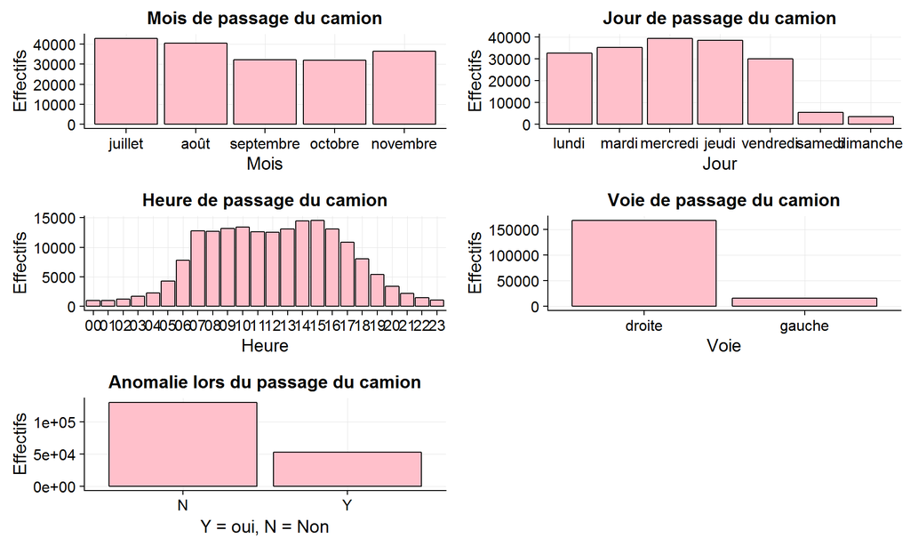

En résumé :

- Les données ont été recueillies durant 5 mois
- Les camions circulent pour la plupart hors week end, et entre 6h et 19h
- Les données enregistrées portent essentiellement sur des camions ayant roulé à droite
- 30 % des camions on déclenché une anomalie au niveau du système de pesage

# 3. Descripteurs des camions (variables quantitatives)

Les variables quantitatives essentiellement des descripteurs physiques de chaque camion.

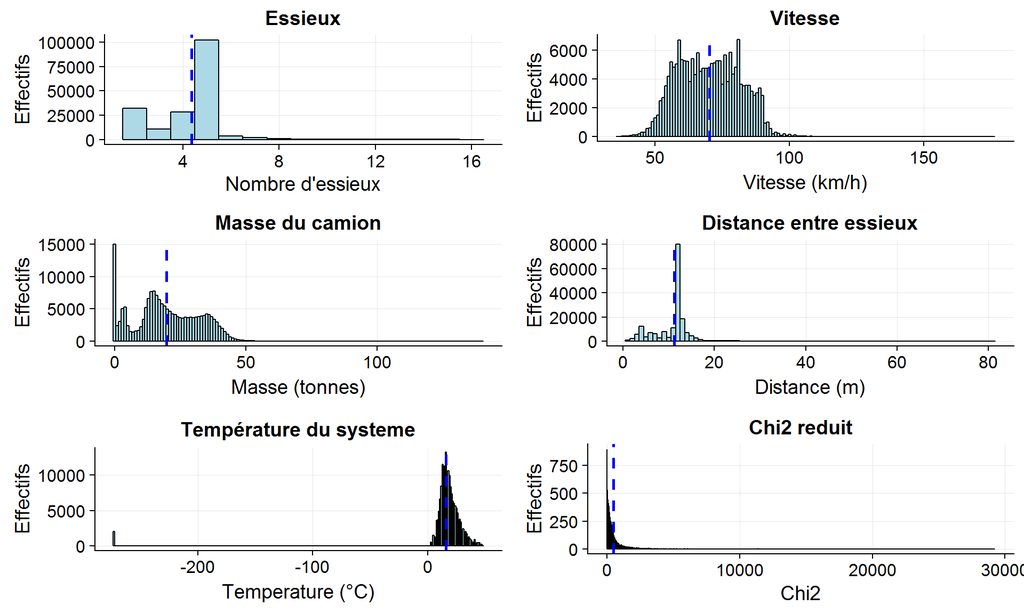

Plusieurs valeurs aberrantes physiquement, des camions :

- Avec 16 essieux
- Roulant à 180 km/h
- Pesant 140 tonnes
- Mesurant 80 mètres

Et une série de températures du sytème observée à -273 °C !

# 4. Traitement des valeurs manquantes et aberrantes

**Idée générale** : attribuer aux données aberrantes une valeur “NA” puis reconstituer leur valeur grace aux techniques d’imputation du package `"missMDA"`.

**Les seuils sont fixés à partir de la connaissance métier**.

Ainsi on considère comme valeure aberrante :

- un nombre d’essieux supérieur à 8
- une distance totale entre les axes > à 20 m
- les températures négatives < à -10°C
- la vitesse d’un camion > à 130 km/h
- la masse d’un camion > à 70 T ou égale à 0

Le remplacement des valeurs aberrantes par “NA” génère donc des valeurs manquantes :

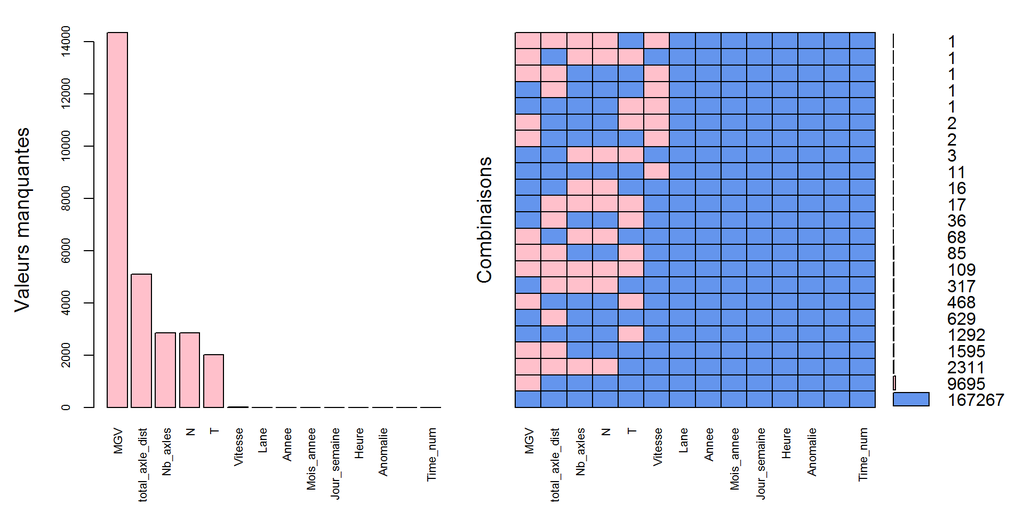

```
##
##  Variables sorted by number of missings:
##             Variable Count
##                  MGV 14338
##      total_axle_dist  5102
##             Nb_axles  2843
##                    N  2843
##                    T  2014
##              Vitesse    19
##                 Lane     0
##                Annee     0
##           Mois_annee     0
##         Jour_semaine     0
##                Heure     0
##             Anomalie     0
##  Reduced_chi_squared     0
##             Time_num     0
```

L’imputation est réalisée par analyse factorielle des données multiples (fonction `imputeFAMD`) du package `MissMDA`.

## Comparaison graphique post-imputation

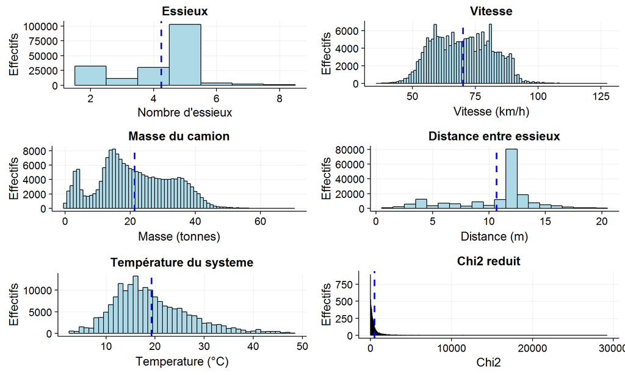

L’imputation semble donner de bons résultats. Etant basée sur une méthode d’estimation, les valeurs imputées peuvent de nouveaux franchir les limites fixées. Nous pouvons soit les supprimer, soit imputer aux valeurs limites de manière à conserver la donnée et donc le plus d’information possible.

La deuxième approche consiste à éliminer les individus ayant des valeurs manquantes et / ou aberrantes.

# 5. Analyse bidimensionnelle (étude des liaisons)

## 5.1 Etude des liaisons entre variables qualitatives (V de Cramer)

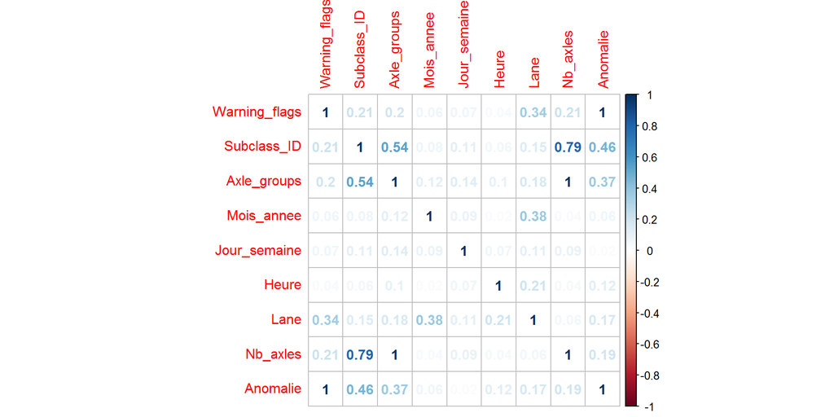

Le V de Cramer offre une mesure absolue (valeur comprise de 0 à 1), de l’intensité de la liaison entre deux variables qualitatives.

Liaison forte (V > 0.3) entre :

- la classification réalisée par le système `SubClasss_ID` et le groupe d’essieux `Axle_Group` (V = 0.54)
- la classification réalisée par le système `SubClasss_ID` et `Nb_axles` le nombre d’essieux

Liaison totale (V = 1) entre :

- `Warning_flags` et `Anomalie`(variable reconstruite signalant la présente d’un warning)
- Le nombre d’essieux `Nb_axles` et le groupe d’essieux `Axle_Group`

## 5.2 Etude des liaisons entre variables quantitatives (corrélation de Pearson)

Nous calculons le coefficient de corrélation linéaire de Pearson entre les variables quantitatives :

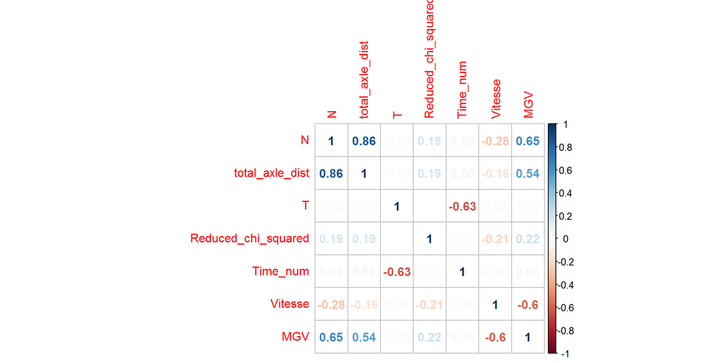

Nous constatons de nombreuses relations linéaires entre les grandeurs physiques (masse, longueur, vitesse,…)